```r
library(dplyr)
library(cluster)
library(visdat)
library(caret)
library(glmnet)
library(GGally)
```

Vasmos a cargar el dataset de AirBnB descargado de aquí

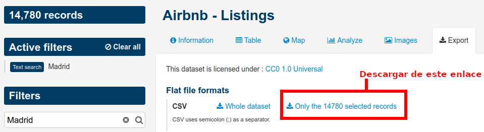

```r
airbnb<-read.csv('airbnb-listings.csv',sep = ';')
options(repr.plot.height=4,repr.plot.width=6,repr.plot.res = 300)
```

1. Vamos a quedarnos con las columnas de mayor interés: ‘City’,‘Room.Type’,‘Neighbourhood’,‘Accommodates’,‘Bathrooms’,‘Bedrooms’,‘Beds’,‘Price’,‘Square.Feet’,‘Guests.Included’,‘Extra.People’,‘Review.Scores.Rating’,‘Latitude’, ‘Longitude’ Nos quedarmos solo con las entradas de Madrid para Room.Type==“Entire home/apt” y cuyo barrio (Neighbourhood) no está vacio ’’ Podemos eliminar las siguientes columnas que ya no son necesarias: “Room.Type”,‘City’ Llama a nuevo dataframe df_madrid.

```r
columnas_seleccionadas <- c('Neighbourhood','Accommodates','Bathrooms','Bedrooms','Beds','Price','Square.Feet','Guests.Included','Extra.People','Review.Scores.Rating','Latitude', 'Longitude')

# Filtramos por el siguiente orden en el pipeline:
#   - Columna Room.Type sea igual a "Entire home/apt"
#   - Columna Neighbourhood no esté vacia
#   - Nos quedamos con las columnas de mayor interés
df_madrid <-
  airbnb |>
     dplyr::filter(City == "Madrid" , Room.Type == "Entire home/apt" , Neighbourhood != "") |>
    dplyr::select(columnas_seleccionadas)
```

2. Crea una nueva columna llamada Square.Meters a partir de Square.Feet. Recuerda que un pie cuadrado son 0.092903 metros cuadrados.

```r
df_madrid$Square.Meters <- df_madrid$Square.Feet *  0.092903
```

3. ¿Que porcentaje de los apartamentos no muestran los metros cuadrados? Es decir, ¿cuantos tienen NA en Square.Meters?

```r
n_filas_na <- df_madrid$Square.Feet |> is.na() |> sum()
n_filas    <- nrow(df_madrid)

cat("Hay ",n_filas ," entradas de las cuales hay ",n_filas_na," con Square.Feet NA.\nEl porcentaje de los apartamentos tienen NA en Square.Meters es",round((n_filas_na/n_filas)*100,2),"%")
```

```
## Hay  5601  entradas de las cuales hay  5254  con Square.Feet NA.
## El porcentaje de los apartamentos tienen NA en Square.Meters es 93.8 %
```

4. De todos los apartamentos que tienen un valor de metros cuadrados diferente de NA ¿Que porcentaje de los apartamentos tienen 0 metros cuadrados?

```r
n_filas_not_na <- df_madrid |> filter(!is.na(Square.Meters)) |> nrow()
n_filas_0      <- df_madrid |> filter(Square.Meters == 0) |> nrow()

cat("Hay",n_filas_not_na ,"entradas no vacías por Square.Meters \nde las cuales hay ",n_filas_0,"con Square.Feet a 0.\nEs lporcentaje de los apartamentos tienen 0 metros cuadrados es",round((n_filas_0/n_filas_not_na)*100,2),"%")
```

```
## Hay 347 entradas no vacías por Square.Meters
## de las cuales hay  128 con Square.Feet a 0.
## Es lporcentaje de los apartamentos tienen 0 metros cuadrados es 36.89 %
```

5. Reemplazar todos los 0m^2 por NA

```r
df_madrid <-
  df_madrid |>
  mutate(Square.Meters = ifelse(Square.Meters == 0, NA, Square.Meters))
```

Hay muchos NAs, vamos a intentar crear un modelo que nos prediga cuantos son los metros cuadrados en función del resto de variables para tratar de rellenar esos NA. Pero **antes de crear el modelo** vamos a hacer: * pintar el histograma de los metros cuadrados y ver si tenemos que filtrar algún elemento más. * crear una variable sintética nueva basada en la similitud entre barrios que usaremos en nuestro modelo.

6. Pinta el histograma de los metros cuadrados y ver si tenemos que filtrar algún elemento más

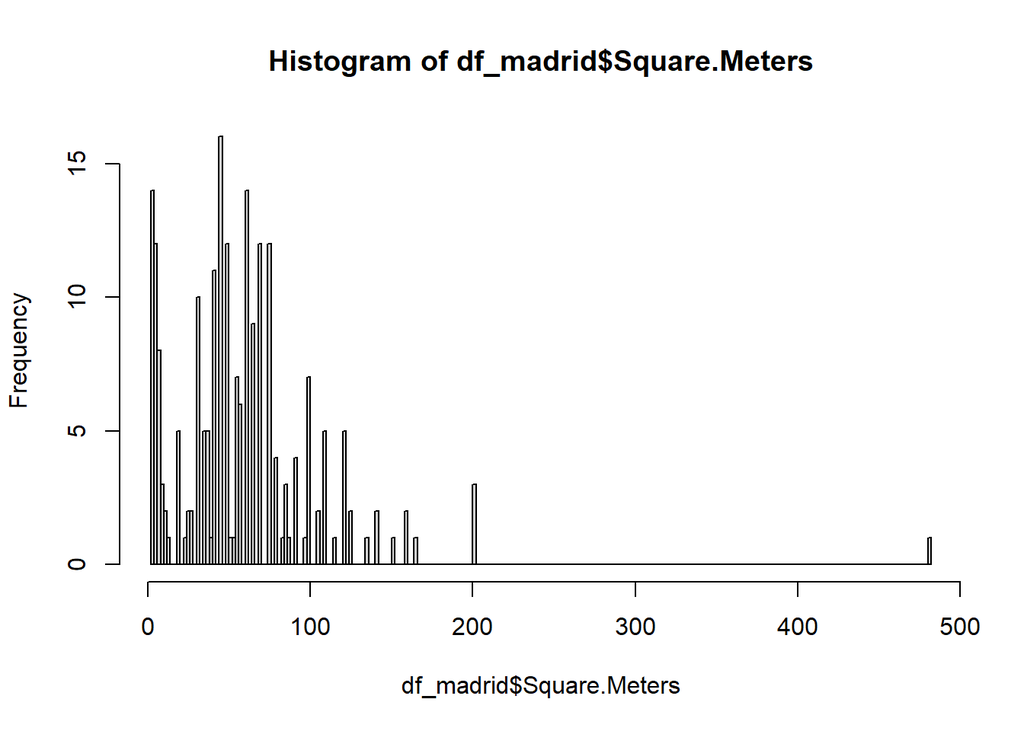

```r
hist(df_madrid$Square.Meters,breaks = 200)
```

7. Asigna el valor NA a la columna Square.Meters de los apartamentos que tengan menos de 20 m^2

```r
df_madrid <-
  df_madrid |>
  mutate(Square.Meters = ifelse(Square.Meters < 20 , NA , Square.Meters))
```

8. Existen varios Barrios que todas sus entradas de Square.Meters son NA, vamos a eliminar del dataset todos los pisos que pertenecen a estos barrios.

```r
barrios_completos <-
  df_madrid |>
  group_by(Neighbourhood) |>
  summarise(count_pisos_barrio=n() ,count_na = sum(is.na(Square.Meters)))|>
  filter(count_pisos_barrio != count_na)|>
  pull(Neighbourhood)

df_madrid <-
  df_madrid |>
  filter(Neighbourhood %in% barrios_completos)

cat("Hay " ,length(unique(df_madrid$Neighbourhood)) , "barrios todas sus entradas de Square.Meters no son NA.\n Los barrios son: \n" , paste0(barrios_completos, sep = ","))
```

```
## Hay  38 barrios todas sus entradas de Square.Meters no son NA.
##  Los barrios son:
##  Acacias, Adelfas, Almagro, Almenara, Arapiles, Argüelles, Barajas, Carabanchel, Castellana, Castilla, Centro, Chamberí, Ciudad Jardin, Ciudad Lineal, Cortes, Cuatro Caminos, El Tréntaiseis, El Viso, Embajadores, Fuente del Berro, Goya, Jerónimos, Justicia, La Latina, Lista, Malasaña, Moratalaz, …
```

El barrio parece ser un indicador importante para los metros cuadrados de un apartamento.

Vamos a agrupar los barrios por metros cuadrados. Podemos usar una matriz de similaridad de Tukey tal y como hicimos en el curso de estadística:

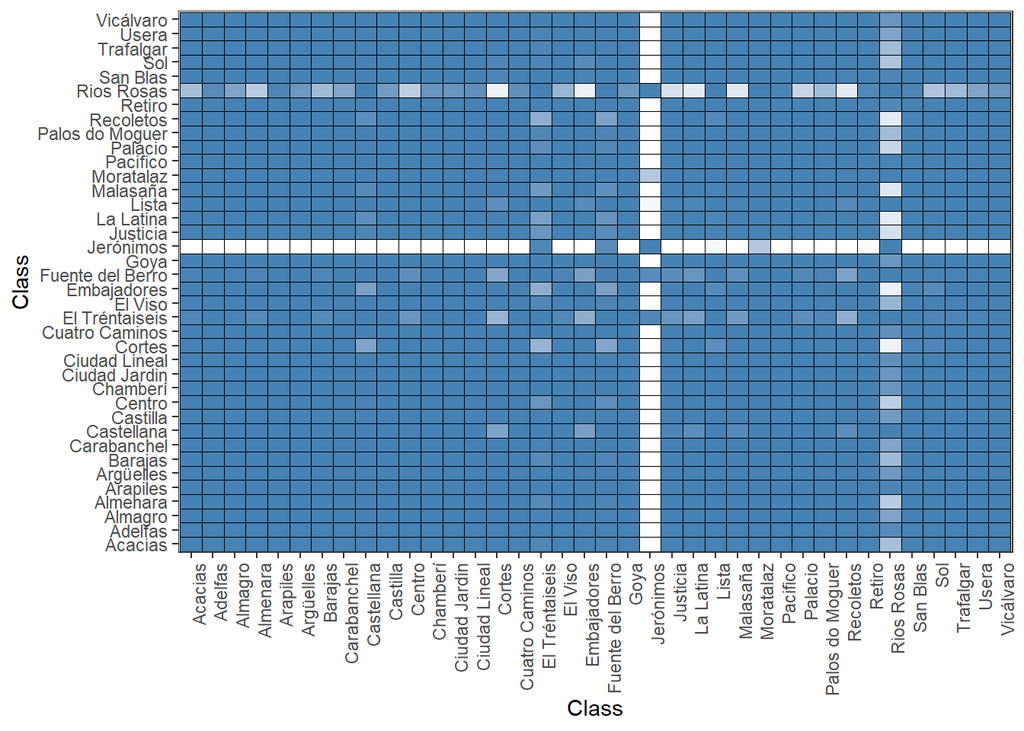

```r
tky<-TukeyHSD(aov( formula=Square.Meters~Neighbourhood, data=df_madrid ))
tky.result<-data.frame(tky$Neighbourhood)
cn <-sort(unique(df_madrid$Neighbourhood))
resm <- matrix(NA, length(cn),length(cn))
rownames(resm) <- cn
colnames(resm) <- cn
resm[lower.tri(resm) ] <- round(tky.result$p.adj,4)
resm[upper.tri(resm) ] <- t(resm)[upper.tri(resm)]
diag(resm) <- 1
library(ggplot2)
library(reshape2)
dfResm <- melt(resm)
ggplot(dfResm, aes(x=Var1, y=Var2, fill=value))+
  geom_tile(colour = "black")+
  scale_fill_gradient(low = "white",high = "steelblue")+
  ylab("Class")+xlab("Class")+theme_bw()+
  theme(axis.text.x = element_text(angle = 90, hjust = 1),legend.position="none")
```

------------------------------------------------------------------------

9. Usando como variable de distancia: 1-resm Dibuja un dendrograma de los diferentes barrios.

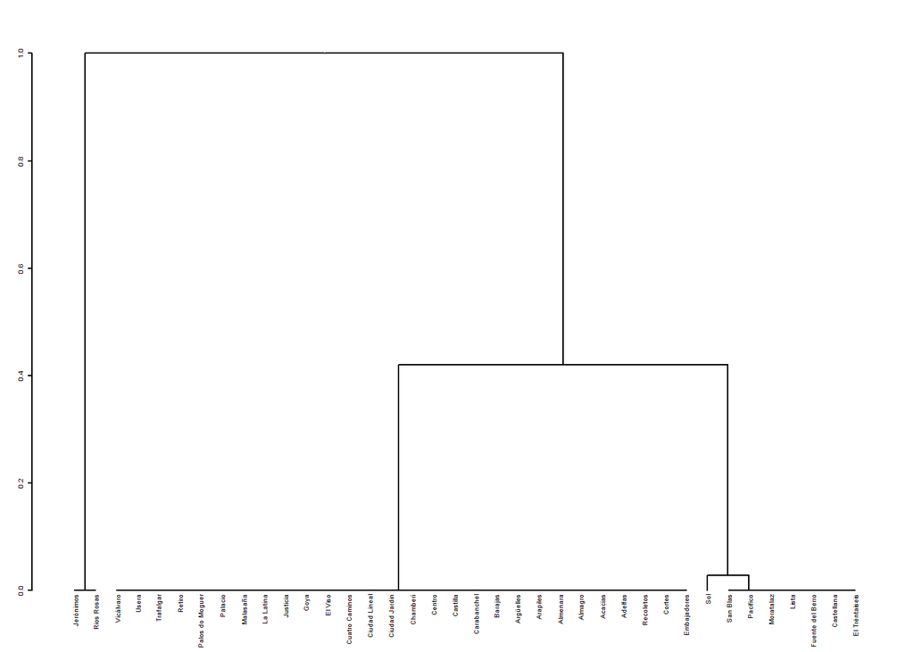

```r
d <- as.dist(1-resm)
hc <- hclust(d,method="complete")
hcd <- as.dendrogram(hc)
par(cex=0.3)
plot(hcd)
```

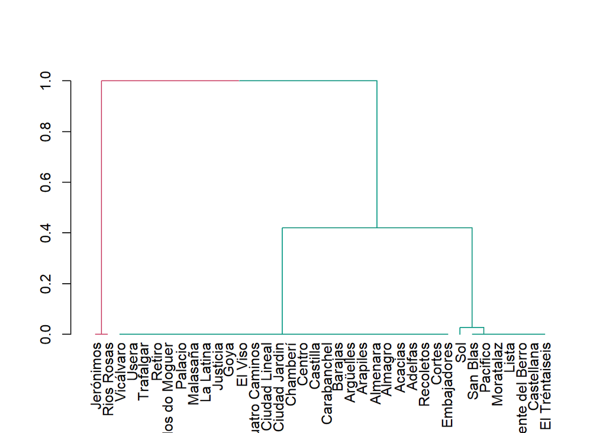

```r
library(dendextend)
#Otra opción es usar la librería dendextend que hace un diagrama más visual. Usamos de altura 0.5 como ejemplo pero en el siguiente punto profundizaremos más en ello.

dend_colored<-color_branches(hcd, h=0.5)
plot(dend_colored)
```

10. ¿Que punto de corte sería el aconsejable?, ¿cuantos clusters aparecen?

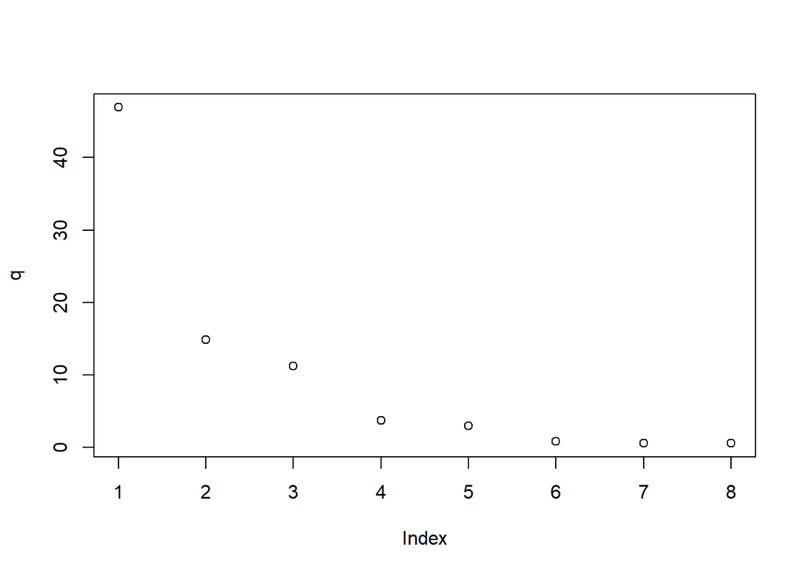

```r
q<-c()
for (k in 1:8){
    myclust<-kmeans(d,k)
    q[k]<-sum(myclust$withinss)
}
plot(q)
```

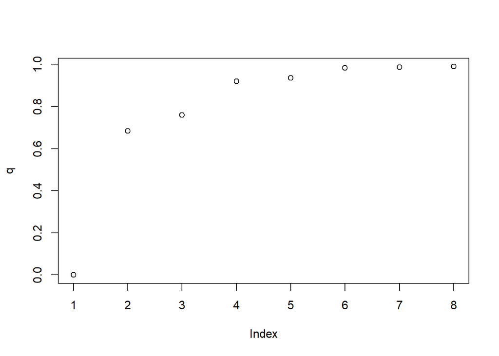

```r
q<-c()
for (k in 1:8){
    myclust<-kmeans(d,k)
    q[k]<-myclust$betweenss/myclust$totss
}
plot(q)
```

No existe una regla fija para determinar el número de grupos.

Podemos pintar como evoluciona el error cuadrádico y cuando deje de mejorar rápidamente establecer como el número de clusters.

En este ejemplo el “codo” no ha salido muy pronunciado. El valor estaría entre 2 y 3 . Cogeremos 3 para este caso.

Aplicamos Silhouette para ver los grupos

```r
k<-3
myclust<-kmeans(d,k)
ss<-silhouette(myclust$cluster,d)
summary(ss)
```

```
## Silhouette of 38 units in 3 clusters from silhouette.default(x = myclust$cluster, dist = d) :
##  Cluster sizes and average silhouette widths:
##         22         15          1
## -0.4614265  0.9712623  0.0000000
## Individual silhouette widths:
##    Min. 1st Qu.  Median    Mean 3rd Qu.    Max.
## -1.0000 -1.0000  0.8007  0.1163  0.9999  1.0000
```

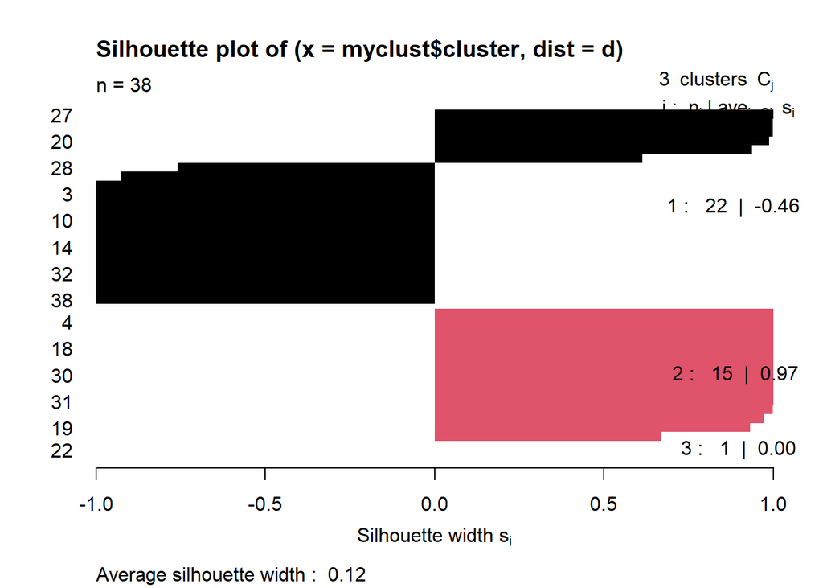

```r
plot(ss,col=1:k,border=NA)
```

11. Vamos a crear una nueva columna en el dataframe df_madrid con un nuevo identificador marcado por los clusters obtenidos. Esta columna la llamaremos neighb_id

```r
df_madrid  <-
  df_madrid |>
  mutate(neighb_id = myclust$cluster[Neighbourhood])
```

12. Vamos a crear dos grupos, uno test y otro train.

Antes de realizar los grupos de test y train , nos quedaremos con aquellas columnas que sean númericas.

Square.Feet tampoco nos hace falta porque ya tenemos Square.Meters y ademas tiene dependencia con la variable que luego vamos a predecir.

```r
numeric_cols <- sapply(df_madrid, is.numeric)
numeric_cols["Square.Feet"] <- FALSE
df_madrid <- df_madrid[, numeric_cols]
df_madrid_completo <- df_madrid
```

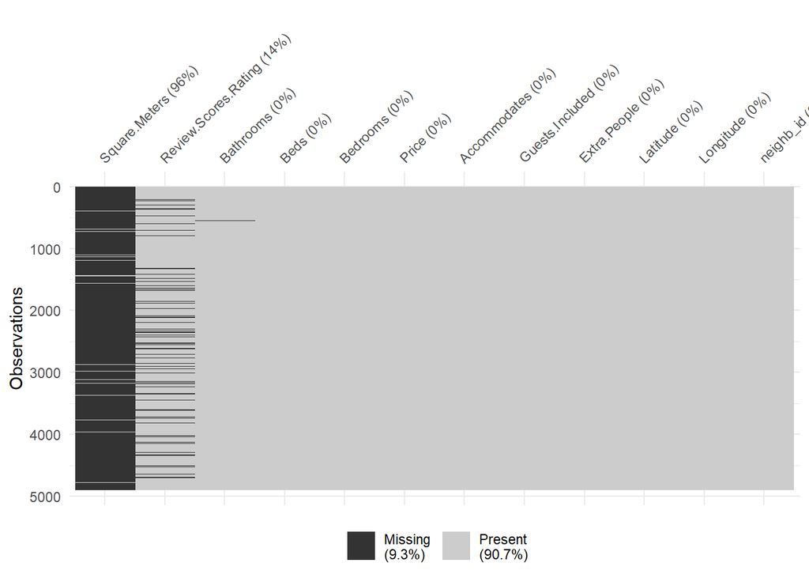

```r
vis_miss(df_madrid,sort_miss = TRUE)
```

Como se puede observar del anterior gráfico , muchas de las observaciones tiene Square.Meters NA y esto es un problema porque es lo que vamos a predecir y debido a que vamos a usar algoritmos supervisados necesitamos solo observaciones donde dicha características aporte información.

```r
df_madrid <- df_madrid[complete.cases(df_madrid), ]
```

Utilizando las variables numéricas y usando las entradas necesarias procederemos a crear los grupos de train y test.

```r
set.seed(1)
itrain<-sample(1:nrow(df_madrid),round(nrow(df_madrid)*0.7))
df_madrid.train<- df_madrid[itrain,]
df_madrid.test <- df_madrid[-itrain,]
```

Por último vamos a realizar una estandarización de los datos para que todos tengna una media de 0 y una desviación de 1 para lograr uniformidad y consistencia en los datos.

Primero aplicaremos la estandarización a el conjunto de train y se lo aplicaremos a la de conjunto de test.

```r
preProcValues  <- preProcess(df_madrid.train, method = c("center", "scale"))
df_madrid.train <- predict(preProcValues, df_madrid.train)
df_madrid.test <- predict(preProcValues,  df_madrid.test)
```

13. Tratamos de predecir los metros cuadrados en función del resto de columnas del dataframe.